# Modeling and prediction for movies

### 4.2 Final Model

```r
m_final <-lm(pop ~runtime+critics_score+genre+best_pic_nom+best_actress_win+top200_box, data=mdb)
summary(m_final)
```

```
##
## Call:
## lm(formula = pop ~ runtime + critics_score + genre + best_pic_nom +
##     best_actress_win + top200_box, data = mdb)
##
## Residuals:
##      Min       1Q   Median       3Q      Max
## -27.9485  -6.1626   0.2402   6.2601  28.4416
##
## Coefficients:
##                                Estimate Std. Error t value Pr(>|t|)
## (Intercept)                    35.57327    2.55788  13.907  < 2e-16 ***
## runtime                         0.06437    0.02170   2.966  0.00313 **
## critics_score                   0.34466    0.01524  22.613  < 2e-16 ***
## genreAnimation                  2.36855    3.44298   0.688  0.49174
## genreArt House & International  5.21647    2.83977   1.837  0.06669 .
## genreComedy                    -0.90926    1.59460  -0.570  0.56874
## genreDocumentary                8.17374    1.94954   4.193 3.15e-05 ***
## genreDrama                      1.69293    1.37541   1.231  0.21883
## genreHorror                    -4.93614    2.34747  -2.103  0.03588 *
## genreMusical & Performing Arts  7.26443    3.07592   2.362  0.01849 *
## genreMystery & Suspense        -1.26361    1.76037  -0.718  0.47314
## genreOther                      0.62102    2.70998   0.229  0.81882
## genreScience Fiction & Fantasy -5.39134    3.41442  -1.579  0.11484
## best_pic_nomyes                 6.22565    2.22778   2.795  0.00535 **
## best_actress_winyes            -1.29080    1.26027  -1.024  0.30612
## top200_boxyes                   2.75566    2.58502   1.066  0.28682
## ---
## Signif. codes:  0 '***' 0.001 '**' 0.01 '*' 0.05 '.' 0.1 ' ' 1
##
## Residual standard error: 9.588 on 634 degrees of freedom
## Multiple R-squared:  0.6038, Adjusted R-squared:  0.5945
## F-statistic: 64.43 on 15 and 634 DF,  p-value: < 2.2e-16
```

The final model can be expressed in the following formula:

$$\begin{align*}
\hat{pop}=&35.573+0.064\,runtime+0.345\,critics\_score+ 2.369\,genre:Animation \\
&+5.216\,genre:Art\>House\&International-0.909\,genre:Comedy\\
&+8.174\,genre:Documentary+1.693\,genre:Drama-4.936\,genre:Horror\\
&+7.264\,genre:Musical\>\&\>Performing\>Arts-1.264\,genre:Mystery\>\&\>Suspense\\
&+0.621\,genre:Other-5.391\,genre:Science\>Fiction\>\&\>Fantasy+6.226\,best\_pic\_nomyes\\
&-1.291\,best\_actress\_winyes+2.756\,top200\_boxyes
\end{align*}$$

### 4.3 Model Diagnostics

#### 4.3.1 Linearity

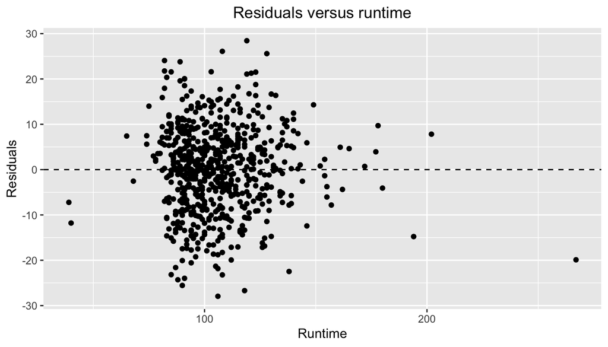

```r
ggplot(data=m_final, aes(x=runtime, y=.resid))+
  geom_point()+
  geom_hline(yintercept=0, linetype="dashed")+
  labs(y="Residuals", title="Residuals versus runtime", x="Runtime")+
  theme(plot.title = element_text(hjust=0.5))
```

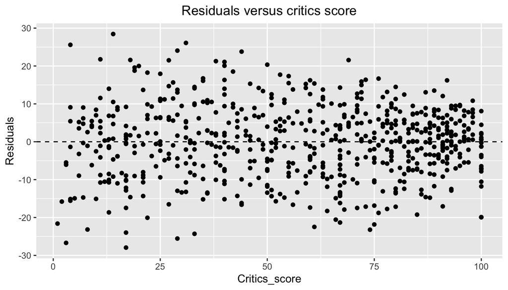

```r
ggplot(data=m_final, aes(x=critics_score, y=.resid))+
  geom_point()+
  geom_hline(yintercept = 0, linetype="dashed")+
  labs(y="Residuals",title="Residuals versus critics score", x="Critics_score")+
  theme(plot.title = element_text(hjust=0.5))
```

The scatterplots of numerical explanatory variables dand residuals both are randomly scattered around 0. The model meets the condition of linearity.

#### 4.3.2 Nearly normal residuals

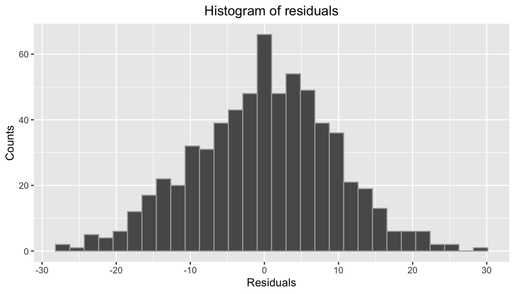

```r
ggplot(data=m_final, aes(x=.resid))+
  geom_histogram(color="darkgray")+
  labs(x="Residuals", title="Histogram of residuals", y="Counts")+
  theme(plot.title=element_text(hjust=0.5))
```

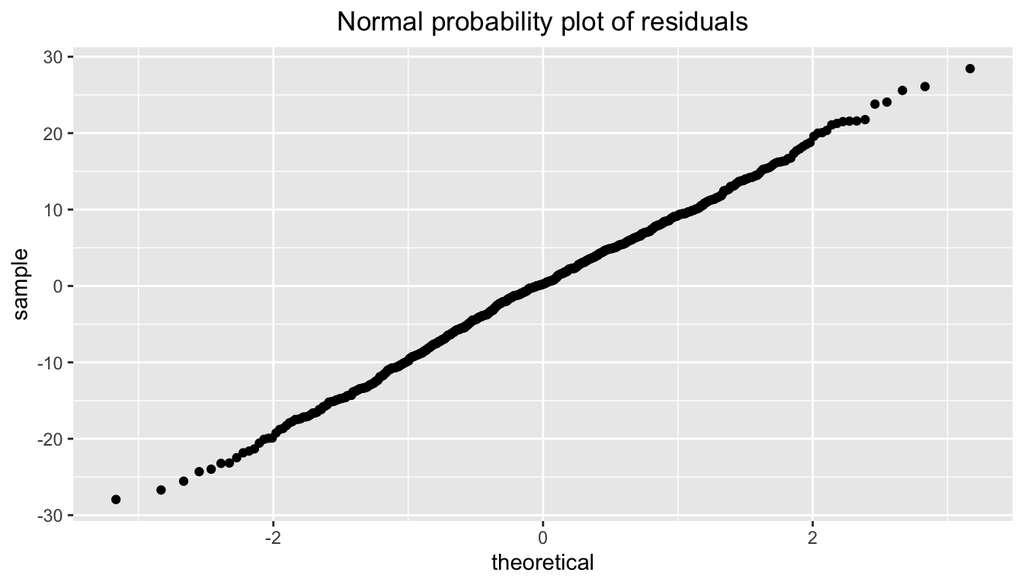

```r
ggplot(data=m_final, aes(sample=.resid))+
  stat_qq()+
  labs(title="Normal probability plot of residuals")+
  theme(plot.title=element_text(hjust=0.5))
```

The histogram of residuals is nearly normal distributed around 0. Except for the tail area, there is not much deviation in the normal probability plot. Therefore, we can confirm the nearly normal residuals.

#### 4.3.3 Constant variability of residuals

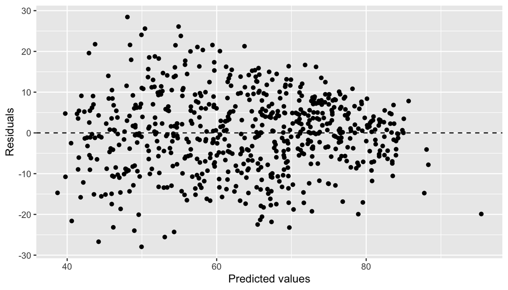

```r
ggplot(data=m_final, aes(x=.fitted, y=.resid))+
  geom_point()+
  geom_hline(yintercept=0,linetype="dashed")+
  labs(x="Predicted values", y="Residuals")
```

There is no fan shape in the scatterplot. The residuals are randomly scattered in a band around 0.

## Part 5: Prediction

In this section, we will use the model to predict the `pop` score of Kung Fu Panda 3 (2016) and quantify the prediction uncertain at a confidence level of 95%. The information of the movie is taken from IMDB and Rotten Tomatoes.

```r
# Input information of Kung Fu Panda 3 (2016)
kp=data.frame(runtime=1*60+35,
               critics_score=87,
               genre="Animation",
               best_pic_nom="no",
               best_actress_win="no",
               top200_box="no")
```

```r
# Make a prediction
predict(m_final, kp,interval = "prediction",level=0.95 )
```

```
##        fit      lwr      upr
## 1 74.04196 54.16052 93.92339
```

The model predicts, with 95% confidence, that Kung Fu Panda 3, an animation with 95 minutes `runtime`, 87 `critics_score`, not nominated the best picture, not winning best actress, and not among top 200 box office, is expected to have a `pop`score from 54.160 to 93.923, and that its pop score is expected to be on average 74.04.

```r
# The actual pop score
real_pop=7.1*5+78/2
real_pop
```

```
## [1] 74.5
```

The actual `pop` score for Kung Fu Panda 3, which is 74.5, is in the 95% confidence interval and is close to the expected,average value.

## Part 6: Conclusion

The answer to the research question is yes. We can use movies’ runtime, critics score, genre, whether nominated in best picture and best actress in Oscar, and whether or not in top 200 box office to predict its popularity, which is gauged by the combination of IMDB rating and audience score from Rotten Tomatoes. Among explanatory variables, `critics_score` is a significant predictor. Even though the final model gives a decent prediction, the model has a few shortcomings

- The adjusted $R^2$ indicates only 59.45% of the variability in the `pop` score can be explained by the model. In terms of the adjusted $R^2$, the improvement of the final model, comparing with the initial full model, is subtle.
- This research ignores that movies are usually categorized into more than one group. For example, Avengers: Endgame is considered action, adventure, and drama.

For future research, in addition to addressing the shortcomings, we can use time series analysis to explore the pop score variation by movie releasing date and DVD releasing date.